# Titanic Survival with Logistic Regression and Decision Tree

Sharmistha Maitra

July 10, 2018

```r
library(ISLR)
library(tidyverse)
library(broom)
library(rpart)
library(partykit)
library(ROCR)
```

# **PROJECT DESCRIPTION:Compare the performance of Logistic regression vs Decision Tree for Survival Prediction of titanic pasengers. Use Titanic dataset from Kaggle**

# **LOADING TITANIC DATA**

## Load the train.csv dataset into R. Convert the target variable to a factor because it will be loaded into R as an integer by default.

```r
#1460 observations and 81 columns.
Train_file_path <- "/Users/sharmisthamaitra/compscix-415-2-assignments/Train.csv"
Train_data <- read.table(Train_file_path,
              header = TRUE,
               sep=","
               )
head(Train_data)
```

```
##   PassengerId Survived Pclass
## 1           1        0      3
## 2           2        1      1
## 3           3        1      3
## 4           4        1      1
## 5           5        0      3
## 6           6        0      3
##                                                  Name    Sex Age SibSp
## 1                             Braund, Mr. Owen Harris   male  22     1
## 2 Cumings, Mrs. John Bradley (Florence Briggs Thayer) female  38     1
## 3                              Heikkinen, Miss. Laina female  26     0
## 4        Futrelle, Mrs. Jacques Heath (Lily May Peel) female  35     1
## 5                            Allen, Mr. William Henry   male  35     0
## 6                                    Moran, Mr. James   male  NA     0
##   Parch           Ticket    Fare Cabin Embarked
## 1     0        A/5 21171  7.2500              S
## 2     0         PC 17599 71.2833   C85        C
## 3     0 STON/O2. 3101282  7.9250              S
## 4     0           113803 53.1000  C123        S
## 5     0           373450  8.0500              S
## 6     0           330877  8.4583              Q
```

```r
#Train_data_1 <- Train_data %>% mutate(Survived_fctr = case_when(
#  Survived == 1 ~ 'Yes',
#  Survived == 0 ~ 'No'
#))

dim(Train_data)
```

```
## [1] 891  12
```

```r
Train_data_1 <- Train_data %>% mutate(Survived = as.factor(Survived))
head(Train_data_1)
```

```
##   PassengerId Survived Pclass
## 1           1        0      3
## 2           2        1      1
## 3           3        1      3
## 4           4        1      1
## 5           5        0      3
## 6           6        0      3
##                                                  Name    Sex Age SibSp
## 1                             Braund, Mr. Owen Harris   male  22     1
## 2 Cumings, Mrs. John Bradley (Florence Briggs Thayer) female  38     1
## 3                              Heikkinen, Miss. Laina female  26     0
## 4        Futrelle, Mrs. Jacques Heath (Lily May Peel) female  35     1
## 5                            Allen, Mr. William Henry   male  35     0
## 6                                    Moran, Mr. James   male  NA     0
##   Parch           Ticket    Fare Cabin Embarked
## 1     0        A/5 21171  7.2500              S
## 2     0         PC 17599 71.2833   C85        C
## 3     0 STON/O2. 3101282  7.9250              S
## 4     0           113803 53.1000  C123        S
## 5     0           373450  8.0500              S
## 6     0           330877  8.4583              Q
```

# **SPLITTING DATA INTO TRAINNG AND TEST DATASETS**

## Randomly split the data into training and test datasets. Using a 70/30 split and random seed of 29283 so that

## same training and test set is generated in each run.

```r
#FIRST METHOD - Creating training and test set using sample_frac().
#Check results => training set should have 624 records, test set should have 267 records
set.seed(29283)

train_set <- Train_data_1 %>% sample_frac(0.7)
head(train_set)
```

```
##     PassengerId Survived Pclass                           Name    Sex Age
## 13           13        0      3 Saundercock, Mr. William Henry   male  20
## 389         389        0      3           Sadlier, Mr. Matthew   male  NA
## 74           74        0      3    Chronopoulos, Mr. Apostolos   male  26
## 351         351        0      3         Odahl, Mr. Nils Martin   male  23
## 867         867        1      2   Duran y More, Miss. Asuncion female  27
## 712         712        0      1             Klaber, Mr. Herman   male  NA
##     SibSp Parch        Ticket    Fare Cabin Embarked
## 13      0     0     A/5. 2151  8.0500              S
## 389     0     0        367655  7.7292              Q
## 74      1     0          2680 14.4542              C
## 351     0     0          7267  9.2250              S
## 867     1     0 SC/PARIS 2149 13.8583              C
## 712     0     0        113028 26.5500  C124        S
```

```r
test_set <- Train_data_1 %>% sample_frac(0.3)
head(test_set)
```

```
##     PassengerId Survived Pclass                                    Name
## 11           11        1      3         Sandstrom, Miss. Marguerite Rut
## 530         530        0      2             Hocking, Mr. Richard George
## 323         323        1      2               Slayter, Miss. Hilda Mary
## 679         679        0      3 Goodwin, Mrs. Frederick (Augusta Tyler)
## 399         399        0      2                        Pain, Dr. Alfred
## 455         455        0      3                     Peduzzi, Mr. Joseph
##        Sex Age SibSp Parch   Ticket  Fare Cabin Embarked
## 11  female   4     1     1  PP 9549 16.70    G6        S
## 530   male  23     2     1    29104 11.50              S
## 323 female  30     0     0   234818 12.35              Q
## 679 female  43     1     6  CA 2144 46.90              S
## 399   male  23     0     0   244278 10.50              S
## 455   male  NA     0     0 A/5 2817  8.05              S
```

```r
#SECOND METHOD - Using PassengerID column and sample_frac() to filter out records for training and test set.
#Check results => training set should have 624 records, test set should have 267 records

set.seed(29283)

train_set <- Train_data_1 %>% sample_frac(.7)
head(train_set)
```

```
##     PassengerId Survived Pclass                           Name    Sex Age
## 13           13        0      3 Saundercock, Mr. William Henry   male  20
## 389         389        0      3           Sadlier, Mr. Matthew   male  NA
## 74           74        0      3    Chronopoulos, Mr. Apostolos   male  26
## 351         351        0      3         Odahl, Mr. Nils Martin   male  23
## 867         867        1      2   Duran y More, Miss. Asuncion female  27
## 712         712        0      1             Klaber, Mr. Herman   male  NA
##     SibSp Parch        Ticket    Fare Cabin Embarked
## 13      0     0     A/5. 2151  8.0500              S
## 389     0     0        367655  7.7292              Q
## 74      1     0          2680 14.4542              C
## 351     0     0          7267  9.2250              S
## 867     1     0 SC/PARIS 2149 13.8583              C
## 712     0     0        113028 26.5500  C124        S
```

```r
test_set <- Train_data_1 %>% filter(!(PassengerId %in% train_set$PassengerId))
head(test_set)
```

```
##   PassengerId Survived Pclass
## 1           1        0      3
## 2           2        1      1
## 3           5        0      3
## 4          12        1      1
## 5          19        0      3
## 6          23        1      3
##                                                      Name    Sex Age SibSp
## 1                                 Braund, Mr. Owen Harris   male  22     1
## 2     Cumings, Mrs. John Bradley (Florence Briggs Thayer) female  38     1
## 3                                Allen, Mr. William Henry   male  35     0
## 4                                Bonnell, Miss. Elizabeth female  58     0
## 5 Vander Planke, Mrs. Julius (Emelia Maria Vandemoortele) female  31     1
## 6                             McGowan, Miss. Anna "Annie" female  15     0
##   Parch    Ticket    Fare Cabin Embarked
## 1     0 A/5 21171  7.2500              S
## 2     0  PC 17599 71.2833   C85        C
## 3     0    373450  8.0500              S
## 4     0    113783 26.5500  C103        S
## 5     0    345763 18.0000              S
## 6     0    330923  8.0292              Q
```

# **FITTING LOGISTIC REGRESSION MODEL to predict survival**

## Fit the model using the glm() function. The target for model is ‘Survived’. Features used - Pclass, Sex, Fare.

## What kind of relationship will these features have with the probability of survival?

## Are these good features, given the problem we are trying to solve?

## After fitting the model, output the coefficients using the broom package and answer these questions:

## How would you interpret the coefficients?

## Are the features significant?

## Use the code below and fill in the blanks.

```r
# Fit a model with Pclass + Sex + Fare

#SOME INSIGHTS
#By intuition, it seems that Pclass , Sex and Fare will have an impact on the probability of survival.
#For example there are more chances of better survival for people travelling in higher class AND those who paid higher fare.

#Interpreting coefficients after fitting the model
#SEX - This has the lowest p-value(1.490440e-35) suggesting that sex of the passenger has a huge impact on the probability of his/her survival.
#FARE - An increase in Fare is associated with an increased probability of survival. A one dollar increase in the Fare increases the log-odds of survival by ~ .002.
mod_1 <- glm(Survived ~ Pclass + Sex + Fare, data = train_set, family = 'binomial')
tidy(mod_1)
```

```
##          term     estimate   std.error   statistic      p.value
## 1 (Intercept)  3.158129368 0.430541964   7.3352417 2.213217e-13
## 2      Pclass -0.875841345 0.145107088  -6.0358274 1.581502e-09
## 3     Sexmale -2.840421241 0.228239516 -12.4449144 1.490440e-35
## 4        Fare  0.001846965 0.002290049   0.8065179 4.199443e-01
```

# **FITTING DECISION TREE MODEL to predict survival**_ ##Now, let’s fit the classification tree model, using the same features(Pclass, Sex, Fare) and target(Survived). ##Plot outcome of the decision tree.Fit the model using the rpart() function.

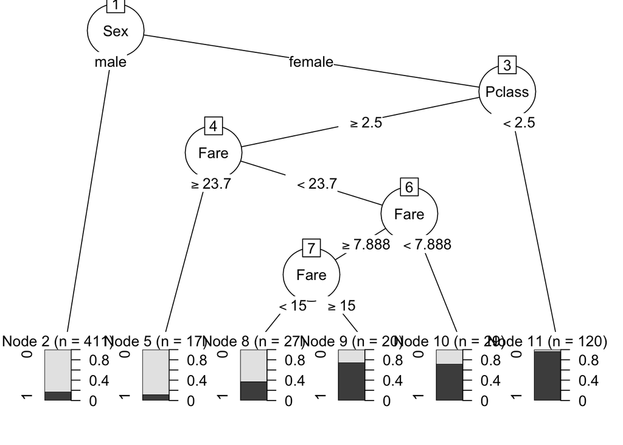

```r
#INSIGHT: A Female passenger had better chance of survival. Following the path in the tree, we have this case a female #passenger who was travelling in higher Pclass (>= 2.5) and paid fare between 15$ and 23.7$ has a high probability of survival.
tree_mod <- rpart(Survived ~ Pclass + Sex + Fare, data = train_set)

plot(as.party(tree_mod))
```

# **NOW TRAINING IS COMPLETE FOR BOTH MODELS(logistic regression and classification tree); LETS EVALUATE MODELS ON TEST DATASET**

## Evaluate both models on the test_set.

## Use predict() function to get the model predictions for the testing set. PRINT FIRST 5 VALUES OF ‘SURVIVED’ (a number

## between 0 and 1 indicating probability of survival, close to 1 means survived) for both models to check the predictions.

```r
test_logit <- predict(mod_1, newdata = test_set, type = 'response')
head(test_logit)
```

```
##          1          2          3          4          5          6
## 0.09141944 0.91788458 0.09154224 0.91143834 0.63734305 0.63307583
```

```r
test_tree <- predict(tree_mod, newdata = test_set)[,2]
head(test_tree)
```

```
##         1         2         3         4         5         6
## 0.1776156 0.9666667 0.1776156 0.9666667 0.7500000 0.3703704
```

# __GET fpr AND tpr FOR BOTH MODELS (logistic regression and classification tree). PLOT ROC CURVES FOR BOTH MODELS TO COMPARE PERFORMANCE

```r
# create the prediction objects for both models
pred_logit <- prediction(predictions = test_logit, labels = test_set$Survived)

pred_tree <- prediction(predictions = test_tree, labels = test_set$Survived)



# get the FPR and TPR for the logistic model
# recall that the ROC curve plots the FPR on the x-axis
perf_logit <- performance(pred_logit, measure = 'tpr', x.measure = 'fpr')
perf_logit_tbl <- tibble(perf_logit@x.values[[1]], perf_logit@y.values[[1]])

# Change the names of the columns of the tibble
names(perf_logit_tbl) <- c('fpr', 'tpr')
head(perf_logit_tbl)
```

```
## # A tibble: 6 x 2
##          fpr        tpr
##        <dbl>      <dbl>
## 1 0.00000000 0.00000000
## 2 0.00000000 0.00952381
## 3 0.00000000 0.01904762
## 4 0.00000000 0.02857143
## 5 0.00617284 0.02857143
## 6 0.00617284 0.04761905
```

```r
# get the FPR and TPR for the tree model
perf_tree <- performance(pred_tree, measure = 'tpr', x.measure = 'fpr')
perf_tree_tbl <- tibble(perf_tree@x.values[[1]], perf_tree@y.values[[1]])

# Change the names of the columns of the tibble
names(perf_tree_tbl) <- c('fpr', 'tpr')
head(perf_tree_tbl)
```

```
## # A tibble: 6 x 2
##          fpr       tpr
##        <dbl>     <dbl>
## 1 0.00000000 0.0000000
## 2 0.03086420 0.4285714
## 3 0.07407407 0.4952381
## 4 0.09876543 0.5809524
## 5 0.14814815 0.6476190
## 6 0.95061728 0.9904762
```

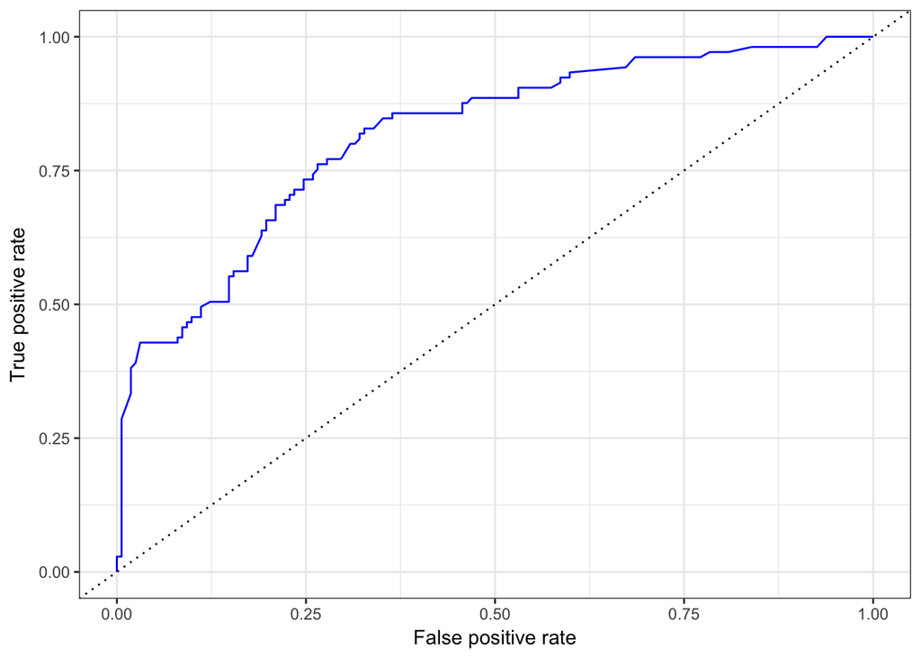

```r
# Plotting function for plotting a nice ROC curve using ggplot
plot_roc <- function(perf_tbl) {
  p <- ggplot(data = perf_tbl, aes(x = fpr, y = tpr)) +
  geom_line(color = 'blue') +
  geom_abline(intercept = 0, slope = 1, lty = 3) +
  labs(x = 'False positive rate', y = 'True positive rate') +
  theme_bw()
  return(p)
}

# Create the ROC curves FOR LOGISTIC REGRESSION model and DECISION TREE
plot_roc(perf_logit_tbl)
```

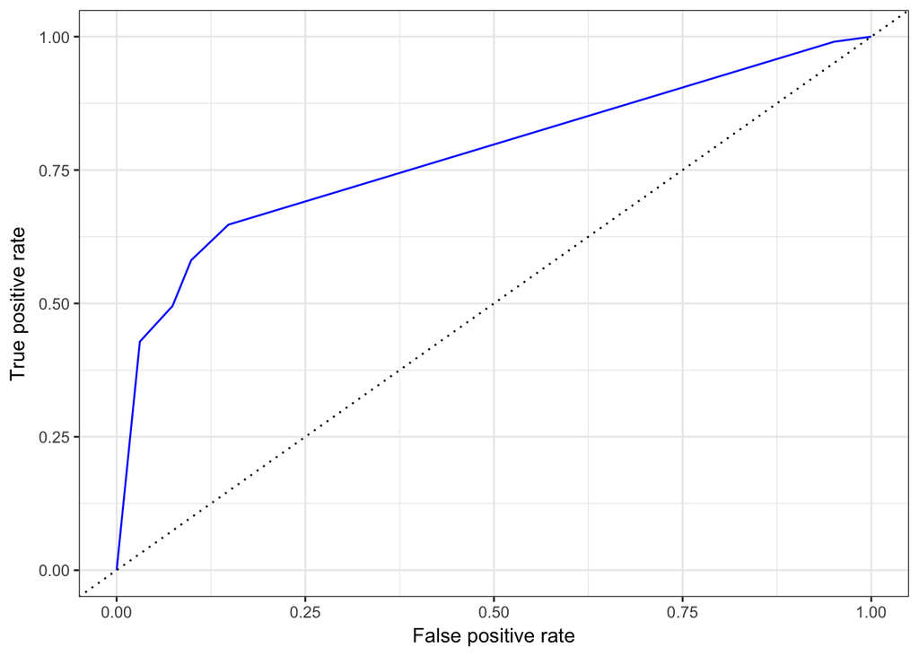

```r
plot_roc(perf_tree_tbl)
```

# __USE performance() function TO CALCULATE AREA UNDER THE CURVE (AUC) FOR BOTH ROC CURVES. ##AUC for LOGISTIC REGRESSION is 0.8147854 AUC for DECISION TREE is 0.776602. As a rule of thumb, a model with good predictive ability should have an AUC closer to 1 (1 is ideal) than to 0.5.

```r
# calculate the AUC FOR BOTH MODELS

auc_logit <- performance(pred_logit, measure = "auc")


auc_tree <- performance(pred_tree, measure = "auc")


# extract the AUC value. AUC for pred_logit is 0.860872. #As a rule of thumb, a model with good predictive ability should have an AUC closer to 1 (1 is ideal) than to 0.5.
auc_logit@y.values[[1]]
```

```
## [1] 0.8147854
```

```r
# extract the AUC value. AUC for pred_tree is 0.8256979 . #As a rule of thumb, a model with good predictive ability should have an AUC closer to 1 (1 is ideal) than to 0.5.
auc_tree@y.values[[1]]
```

```
## [1] 0.776602
```

# **PERFORMANCE EVALUATION FOR BOTH MODELS depending on ROC curves and AUC values. Is the logistic regression model doing better, worse, or about the same as the classification tree?**

## Pick a probability cutoff by looking at the ROC curves.

## 1)Create 4 new columns for the dataset(2 columns for each model predicting probability of survival for each passenger) as decribed below

```r
#Create 2 new columns to hold prediction values(number between 0 and 1) for 'Survived' for Logistic Regression and Decision Tree model
test_set_1 <- test_set %>% mutate(pred_logit_prob = test_logit) %>% mutate(pred_tree_prob = test_tree)


#Create 2 news columns to hold prediction values (Yes or No, depending on chosen cutoff) for 'Survived' for Logistic Regression and Decision Tree model
test_set_2 <- test_set_1 %>% mutate(pred_logit_cat = case_when(pred_logit_prob < .25 ~ 'No',
                                              pred_logit_prob >= .25 ~ 'Yes'))


test_set_3 <- test_set_2  %>% mutate(pred_tree_cat = case_when(pred_tree_prob < .25 ~ 'No',
                                              pred_tree_prob >= .25 ~ 'Yes'))
head(test_set_3)
```

```
##   PassengerId Survived Pclass
## 1           1        0      3
## 2           2        1      1
## 3           5        0      3
## 4          12        1      1
## 5          19        0      3
## 6          23        1      3
##                                                      Name    Sex Age SibSp
## 1                                 Braund, Mr. Owen Harris   male  22     1
## 2     Cumings, Mrs. John Bradley (Florence Briggs Thayer) female  38     1
## 3                                Allen, Mr. William Henry   male  35     0
## 4                                Bonnell, Miss. Elizabeth female  58     0
## 5 Vander Planke, Mrs. Julius (Emelia Maria Vandemoortele) female  31     1
## 6                             McGowan, Miss. Anna "Annie" female  15     0
##   Parch    Ticket    Fare Cabin Embarked pred_logit_prob pred_tree_prob
## 1     0 A/5 21171  7.2500              S      0.09141944      0.1776156
## 2     0  PC 17599 71.2833   C85        C      0.91788458      0.9666667
## 3     0    373450  8.0500              S      0.09154224      0.1776156
## 4     0    113783 26.5500  C103        S      0.91143834      0.9666667
## 5     0    345763 18.0000              S      0.63734305      0.7500000
## 6     0    330923  8.0292              Q      0.63307583      0.3703704
##   pred_logit_cat pred_tree_cat
## 1             No            No
## 2            Yes           Yes
## 3             No            No
## 4            Yes           Yes
## 5            Yes           Yes
## 6            Yes           Yes
```

## 2)Using the probability cutoff, create the confusion matrix for both model.

```r
#
#-------RESULTS OF CONFUSION MATRIX for both models -------------
#Logistic regression CORRECTLY PREDICTED 84 SURVIVALS.
#Decision tree CORRECTLY PREDICTED 68 SURVIVALS.
#Logistic did a better job in reducing the amount of False Negatives. Decision tree did a better job is reducing the amount of false positives.
#AUC for LOGISTIC is 0.8147854 and AUC for TREE is 0.776602 which suggests that Logistic regression is performing slightly better.

#Logistic regression
#————------------------------
#Predicted No, Actual No - 112 (true negatives)
#Predicted No, Actual Yes - 21( false negatives)

#Predicted Yes, Actual Yes - 84 (true positives)
#Predicted Yes, Actual No - 50 ( false positives)

#Classification tree
#————----------------
#Predicted No, Actual No - 138 (true negatives)
#Predicted No, Actual Yes - 37 ( false negatives)

#Predicted Yes, Actual Yes - 68 (true positives)
#Predicted Yes, Actual No - 24 (false positives)

test_set_3 %>% count(pred_logit_cat, Survived) %>% spread(Survived, n)
```

```
## # A tibble: 2 x 3
##   pred_logit_cat   `0`   `1`
## *          <chr> <int> <int>
## 1             No   112    21
## 2            Yes    50    84
```

```r
test_set_3 %>% count(pred_tree_cat, Survived) %>% spread(Survived, n)
```

```
## # A tibble: 2 x 3
##   pred_tree_cat   `0`   `1`
## *         <chr> <int> <int>
## 1            No   138    37
## 2           Yes    24    68
```

# **INCREASE PERFORMANCE OF MODELS by choosing a more meaningful cutoff by looking at the ROC curves**

## Cutoff for logistic => 63.3%

## Cutoff for Tree => 37.0%

# Now Decision Tree giving more accurate prediction, tree correctly predicted 68 survivals compared to logistic which

# predicted 61 survivals.

```r
#Logistic regression
#————------------------------
#Predicted No, Actual No - 134 (true negatives)
#Predicted No, Actual Yes - 44( false negatives)

#Predicted Yes, Actual Yes - 61 (true positives)
#Predicted Yes, Actual No - 28 ( false positives)


#Classification tree
#————----------------
#Predicted No, Actual No - 138 (true negatives)
#Predicted No, Actual Yes - 37 ( false negatives)

#Predicted Yes, Actual Yes - 68 (true positives)
#Predicted Yes, Actual No - 24 (false positives)



# create a tibble of your fpr, tpr and cutoffs
perf_tree_tbl_summary <- tibble(fpr = perf_tree@x.values[[1]], tpr = perf_tree@y.values[[1]], cutoffs = perf_tree@alpha.values[[1]])
#perf_tree_tbl_summary

perf_logit_tbl_summary <- tibble(fpr = perf_logit@x.values[[1]], tpr = perf_logit@y.values[[1]], cutoffs = perf_logit@alpha.values[[1]])
#perf_logit_tbl_summary

# then you can use data wrangling verbs to manipulate your tibble
# and find the cutoff you want to use
perf_tree_tbl_summary %>% filter(fpr < .2 & tpr > .6)
```

```
## # A tibble: 1 x 3
##         fpr      tpr   cutoffs
##       <dbl>    <dbl>     <dbl>
## 1 0.1481481 0.647619 0.3703704
```

```r
perf_logit_tbl_summary %>% filter(fpr < .2 & tpr > .6)
```

```
## # A tibble: 5 x 3
##         fpr       tpr   cutoffs
##       <dbl>     <dbl>     <dbl>
## 1 0.1913580 0.6285714 0.6329560
## 2 0.1913580 0.6380952 0.6329489
## 3 0.1975309 0.6380952 0.6328702
## 4 0.1975309 0.6476190 0.6327415
## 5 0.1975309 0.6571429 0.6327325
```

```r
# I choose to use these cutoff values
p_cutoff_logit <- .633
p_cutoff_tree <- .370

test_set_4 <- test_set %>% mutate(test_logit = test_logit,
                                test_tree = test_tree,
                                class_logit = case_when(test_logit < p_cutoff_logit ~ 'No',
                                                        test_logit >= p_cutoff_logit ~ 'Yes'),
                                class_tree = case_when(test_tree < p_cutoff_tree ~ 'No',
                                                        test_tree >= p_cutoff_tree ~ 'Yes'))
head(test_set_4)
```

```
##   PassengerId Survived Pclass
## 1           1        0      3
## 2           2        1      1
## 3           5        0      3
## 4          12        1      1
## 5          19        0      3
## 6          23        1      3
##                                                      Name    Sex Age SibSp
## 1                                 Braund, Mr. Owen Harris   male  22     1
## 2     Cumings, Mrs. John Bradley (Florence Briggs Thayer) female  38     1
## 3                                Allen, Mr. William Henry   male  35     0
## 4                                Bonnell, Miss. Elizabeth female  58     0
## 5 Vander Planke, Mrs. Julius (Emelia Maria Vandemoortele) female  31     1
## 6                             McGowan, Miss. Anna "Annie" female  15     0
##   Parch    Ticket    Fare Cabin Embarked test_logit test_tree class_logit
## 1     0 A/5 21171  7.2500              S 0.09141944 0.1776156          No
## 2     0  PC 17599 71.2833   C85        C 0.91788458 0.9666667         Yes
## 3     0    373450  8.0500              S 0.09154224 0.1776156          No
## 4     0    113783 26.5500  C103        S 0.91143834 0.9666667         Yes
## 5     0    345763 18.0000              S 0.63734305 0.7500000         Yes
## 6     0    330923  8.0292              Q 0.63307583 0.3703704         Yes
##   class_tree
## 1         No
## 2        Yes
## 3         No
## 4        Yes
## 5        Yes
## 6        Yes
```

```r
test_set_4 %>% count(class_logit, Survived) %>% spread(Survived, n)
```

```
## # A tibble: 2 x 3
##   class_logit   `0`   `1`
## *       <chr> <int> <int>
## 1          No   134    44
## 2         Yes    28    61
```

```r
test_set_4 %>% count(class_tree, Survived) %>% spread(Survived, n)
```

```
## # A tibble: 2 x 3
##   class_tree   `0`   `1`
## *      <chr> <int> <int>
## 1         No   138    37
## 2        Yes    24    68
```